title: “Problem Set 2: Bias, Variance, Cross-Validation” author: “51709” date: | | 01 March 2023 output: pdf_document

### 1a. With predictor `x` and outcome `noisy_y`, split the data into a training and test set

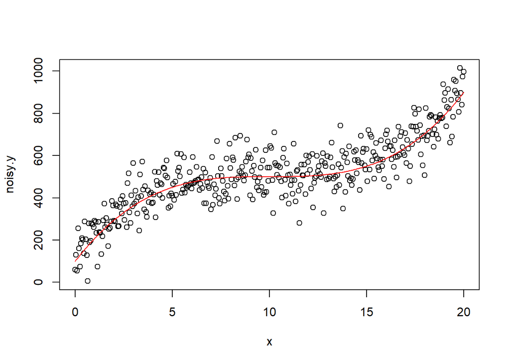

```r
library(boot)
set.seed(1)
x <- seq(from=0, to=20, by=0.05)
y <- 500 + 0.4 * (x-10)^3
noise <- rnorm(length(x), mean=10, sd=80)
noisy.y <- y + noise
{
plot(x,noisy.y)
lines(x, y, col='red')
}
```

Assign the data to a dataframe. Randomly sample the data, assigning 80% to training set and 20% to test set.

```r
df <- data.frame(x, noisy.y)
N <- floor(.8*nrow(df))
train_idx <- sample(1:nrow(df), N)
df_train <- df[train_idx,]
df_test <- df[-train_idx,]
```

### 1b. Perform 10-fold CV for polynomials from degree 1 to 5 (use MSE as your error measure). This should be done from scratch using a for loop.

Randomly permute the training set and split into 10 evenly sized folds. Then create a for loop: for every polynomial model of degree 1 through 5, split the training set again into a training set and test set, with 1 fold in the test set and the rest in the training set. Change which fold is in the test set each time by inserting a nested for loop for i (fold used for test) 1 through 10 (for 10-fold cross-validation).

Calculate the mean-squared error of the test sub-set (validation set) for each fold. Store results from each loop in a results table with column headings for the degree of the model, the fold number and the mean-squared error.

```r
folds <- sample(rep(1:10, each = nrow(df_train)/10), replace=FALSE)
degree <- 1:5
results <- data.frame(results_degree=numeric(0), results_i=numeric(0), results_error=numeric(0))
for (d in degree){
  for (i in 1:10){
    cv.te <- df_train[folds==i,]
    cv.tr <- df_train[folds!=i,]
    cv.tr.x <- cv.tr[,1]
    cv.tr.y <- cv.tr[,2]
    cv.te.x <- cv.te[,1]
    cv.te.y <- cv.te[,2]
    mod <- glm(noisy.y ~ poly(x, d, raw = T), data=df_train)
    row <- data.frame(results_degree=d, results_i=i,     results_error=mean((predict(mod, cv.te) - cv.te$noisy.y)^2))
    results <- rbind(results, row)
    }
}
results
```

```
##    results_degree results_i results_error
## 1               1         1      6420.144
## 2               1         2     10231.589
## 3               1         3      8808.168
## 4               1         4     12982.480
## 5               1         5     10610.066
## 6               1         6      8595.007
## 7               1         7      5252.368
## 8               1         8      6735.810
## 9               1         9      8653.017
## 10              1        10     13536.145
## 11              2         1      6421.101
## 12              2         2     10225.078
## 13              2         3      8810.706
## 14              2         4     12985.486
```

[output cut: 36 more lines]

To calculate the overall cross-validation error for each model, create a table which summarises the cross-validation error for each fold. For each degree 1 through 5, calculate the sum of the MSE’s across the 10 folds (`a`) using an ifelse condition, and calculate the number of folds (`b`). Then divide `a` by `b` to give the average MSE for each of the 5 models being tested.

```r
  summary_table <- data.frame(summary_degree=numeric(0), sum_error =numeric(0), count_error=numeric(0), mean_error=numeric(0))

  a <- 0
  b <- 0
  c <- 0

  for (k in 1:5){
    for (j in 1:nrow(results)){
      ifelse(results[j,1] == k, a <- a + results[j,3], a <- a)
      ifelse(results[j,1] == k, b <- b + 1, b <- b)
    }
    c = a / b
    row <- data.frame(summary_degree = k, sum_error = a, count_error = b, mean_error = c)
    summary_table <- rbind(summary_table, row)
    a = 0
    b = 0
    c = 0
  }
summary_table
```

```
##   summary_degree sum_error count_error mean_error
## 1              1  91824.79          10   9182.479
## 2              2  91824.62          10   9182.462
## 3              3  60496.24          10   6049.624
## 4              4  60495.08          10   6049.508
## 5              5  60216.85          10   6021.685
```

### 1c. Plot the best model’s fitted line in blue and compare to the true function (the red line from the previous plot).

From the table above, the model with the lowest MSE (and therefore the best model) is the degree 5 polynomial.

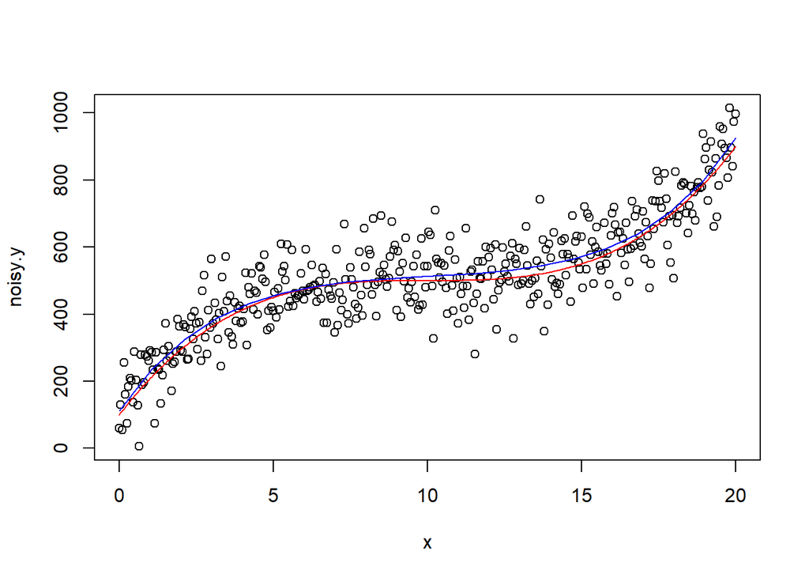

```r
plot(x,noisy.y)
lines(x, y, col='red')
poly5_mod <-lm(noisy.y ~ poly(x, 5, raw = T), data = df_train)
x <- seq(min(df$x), max(df$x), length.out=20)
y <- predict(poly5_mod, newdata = data.frame(x = x))
lines(x, y, col = "blue")
```

### 1.d Comment on the results of (c). Why was performance better or worse at different order polynomials?

Since we generated the data, we know that the true underlying function is a cubic function (with noise added). My 10-fold cross-validation shows that the degree 5 polynomial has the lowest cross-validation error (though this error value is very similar to the polynomials of degrees 3 and 4). We can see from this plot that the 5 degree polynomial model is still visually a good fit to the data points, and stays fairly close to the true function.

We can hazard that the reason a degree 5 model has slightly lower error than degree 3 model may be due to the noise we added to the true function, therefore the 4 and 5 degree models are over-fitting to the noise as the higher the degree of polynomial, the more flexible it is. Cross-validation is only an approximation of the test error so it is possible for over-fitting to occur, however this is more common when the sample size is small.

### 1e. Report the CV error and test error at each order of polynomial. Which achieves the lowest CV error? How does the CV error compare to the test error? Comment on the results.

```r
degree <- 1:5
test_results <- data.frame(degree=numeric(0), test_error=numeric(0))
for (d in degree){
    mod <- glm(noisy.y ~ poly(x, d, raw = T), data=df_test)
    test_row <- data.frame(degree=d,     test_error = mean((predict(mod, df_test) - df_test$noisy.y)^2))
    test_results <- rbind(test_results, test_row)
    }
test_results <- cbind(test_results, summary_table[,4, drop=FALSE])
names(test_results)[names(test_results) == "mean_error"] <- "cross-validation_error"
test_results
```

```
##   degree test_error cross-validation_error
## 1      1  10474.458               9182.479
## 2      2  10299.480               9182.462
## 3      3   5596.121               6049.624
## 4      4   5560.176               6049.508
## 5      5   5558.305               6021.685
```

For both test error and cross-validation error, the error decreases as the degree of the polynomial increases (from 1 through to 5).

The lowest cross-validation error and test error are both for the polynomial of degree 5.

### 2a. Pick a new dataset from the `mlbench` package (one we haven’t used in class that is 2-dimensional with two classes). Experiment with classifying the data using KNN at different values of k. Use cross-validation to choose your best model.

```r
library(mlbench)
library(dplyr)
set.seed(1)
ls(package:mlbench)
```

```
##  [1] "bayesclass"        "mlbench.1spiral"   "mlbench.2dnormals"
##  [4] "mlbench.cassini"   "mlbench.circle"    "mlbench.corners"
##  [7] "mlbench.cuboids"   "mlbench.friedman1" "mlbench.friedman2"
## [10] "mlbench.friedman3" "mlbench.hypercube" "mlbench.peak"
## [13] "mlbench.ringnorm"  "mlbench.shapes"    "mlbench.simplex"
## [16] "mlbench.smiley"    "mlbench.spirals"   "mlbench.threenorm"
## [19] "mlbench.twonorm"   "mlbench.waveform"  "mlbench.xor"
```

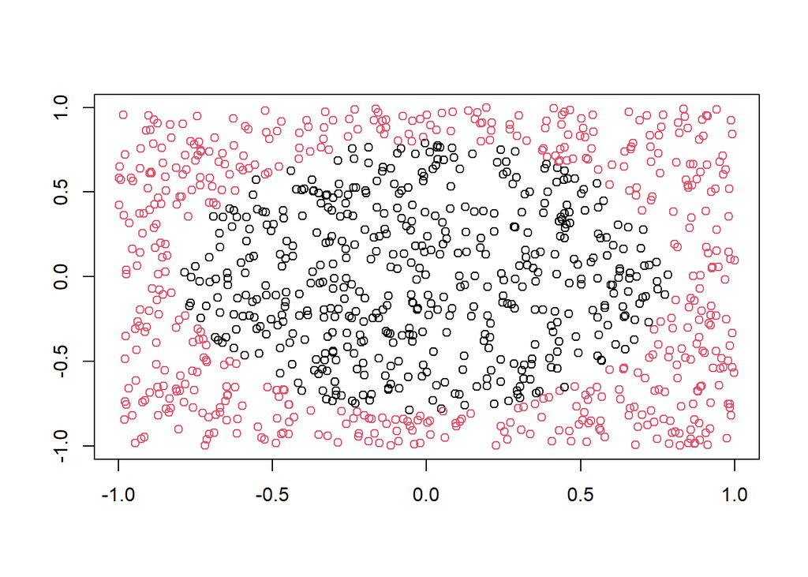

```r
c <- mlbench.circle(1000,2)
plot(c)
```

Move the dataset into a dataframe so it’s easier to work with. Rename variables and set levels of classes.

```r
cdf <- data.frame(c)
cdf <- cdf %>% rename(Y.1 = classes, X.1 = x.1, X.2 = x.2)
levels(cdf$Y.1) <- c("0", "1")
```

Randomly permute the training set and split into 10 evenly sized folds. Then create a for loop: for values 1 through 100 of K, split the training set again into a training set and test set, with 1 fold in the test set and the rest in the training set. Change which fold is in the test set each time by inserting a nested for loop for i (fold used for test) 1 through 10 (for 10-fold cross-validation). Calculate the mean-squared error of the test sub-set (validation sub-set) for each fold. Store results from each loop in a results table with column headings for the value of the k parameter, the fold number and the classification error.

```r
library(class)
n_test <- floor(nrow(cdf)*0.2)
idx <- sample(1:nrow(cdf), n_test)
train <- cdf[-idx,]
test <- cdf[idx,]
folds <- sample(rep(1:10, each = nrow(train)/10), replace=FALSE)
results <- data.frame(results_k=numeric(0), results_i=numeric(0), results_error=numeric(0))
range <- 1:100
for (k in range){
  for (i in 1:10){
  cv.te <- train[folds==i,]
  cv.tr <- train[folds!=i,]
  cv.tr.x <- cv.tr[,1:2]
  cv.tr.y <- cv.tr[,3]
  cv.te.x <- cv.te[,1:2]
  cv.te.y <- cv.te[,3]
  pred.Y <- knn(cv.tr.x, cv.te.x, cv.tr.y, k)
  row <- data.frame(results_k=k, results_i=i, results_error=mean(cv.te.y != pred.Y))
  results <- rbind(results, row)
  }
}
results
```

```
##      results_k results_i results_error
## 1            1         1        0.0625
## 2            1         2        0.0000
## 3            1         3        0.0375
## 4            1         4        0.0125
## 5            1         5        0.0250
## 6            1         6        0.0250
## 7            1         7        0.0000
## 8            1         8        0.0125
## 9            1         9        0.0250
## 10           1        10        0.0125
## 11           2         1        0.1000
## 12           2         2        0.0000
## 13           2         3        0.0500
## 14           2         4        0.0500
```

[output cut: 986 more lines]

```r
  summary_table_k <- data.frame(sum_k=numeric(0), sum_error =numeric(0), count_error=numeric(0), mean_error=numeric(0))

  a <- 0
  b <- 0
  c <- 0

  for (k in range){
    for (j in 1:nrow(results)){
      ifelse(results[j,1] == k, a <- a + results[j,3], a <- a)
      ifelse(results[j,1] == k, b <- b + 1, b <- b)
    }
    c = a / b
    row <- data.frame(sum_k = k, sum_error = a, count_error = b, mean_error = c)
    summary_table_k <- rbind(summary_table_k, row)
    a = 0
    b = 0
    c = 0
  }
summary_table_k
```

```
##     sum_k sum_error count_error mean_error
## 1       1    0.2125          10    0.02125
## 2       2    0.3625          10    0.03625
## 3       3    0.3000          10    0.03000
## 4       4    0.3500          10    0.03500
## 5       5    0.2875          10    0.02875
## 6       6    0.3250          10    0.03250
## 7       7    0.3500          10    0.03500
## 8       8    0.4125          10    0.04125
## 9       9    0.4250          10    0.04250
## 10     10    0.4375          10    0.04375
## 11     11    0.3625          10    0.03625
## 12     12    0.4250          10    0.04250
## 13     13    0.3375          10    0.03375
## 14     14    0.3750          10    0.03750
```

[output cut: 86 more lines]

remove k = 1 as this is unhelpful. Then find the minimum error.

```r
summary_table_k_min <- summary_table_k[-1,]
which(summary_table_k_min == min(summary_table_k_min[,4]), arr.ind=TRUE)
```

```
##    row col
## 16  15   4
```

### 2b. Plot misclassification error rate at different values of k.

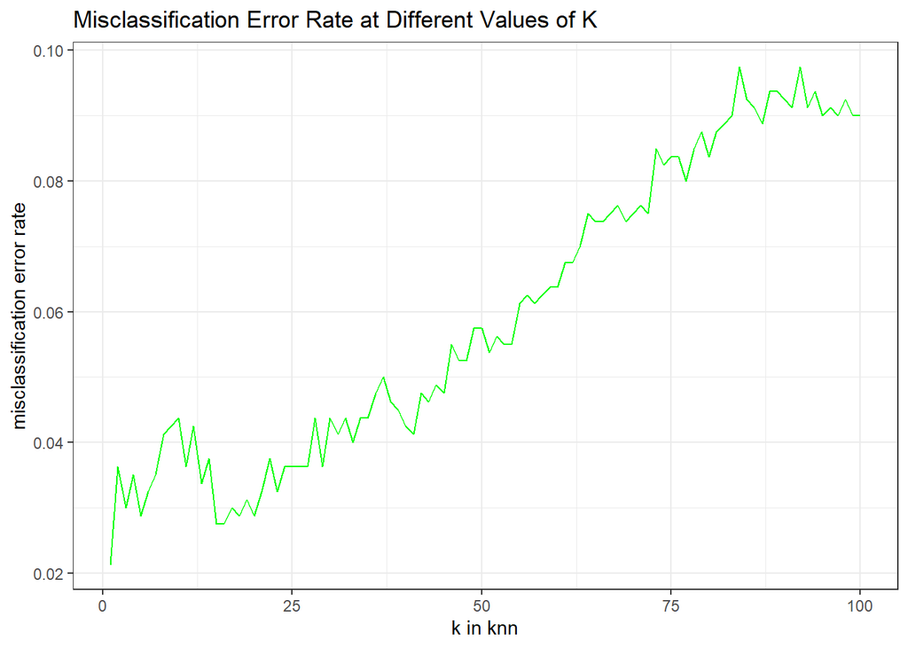

```r
library(ggplot2)
ggplot(summary_table_k, aes(x = sum_k)) +
geom_line(aes(y = mean_error), color = "green") + labs(x = "k in knn", y = "misclassification error rate", title = "Misclassification Error Rate at Different Values of K") + theme_bw()
```

### 2c. Plot the decision boundary for your classifier using the function at the top code block, `plot_decision_boundary()`. Make sure you load this function into memory before trying to use it.

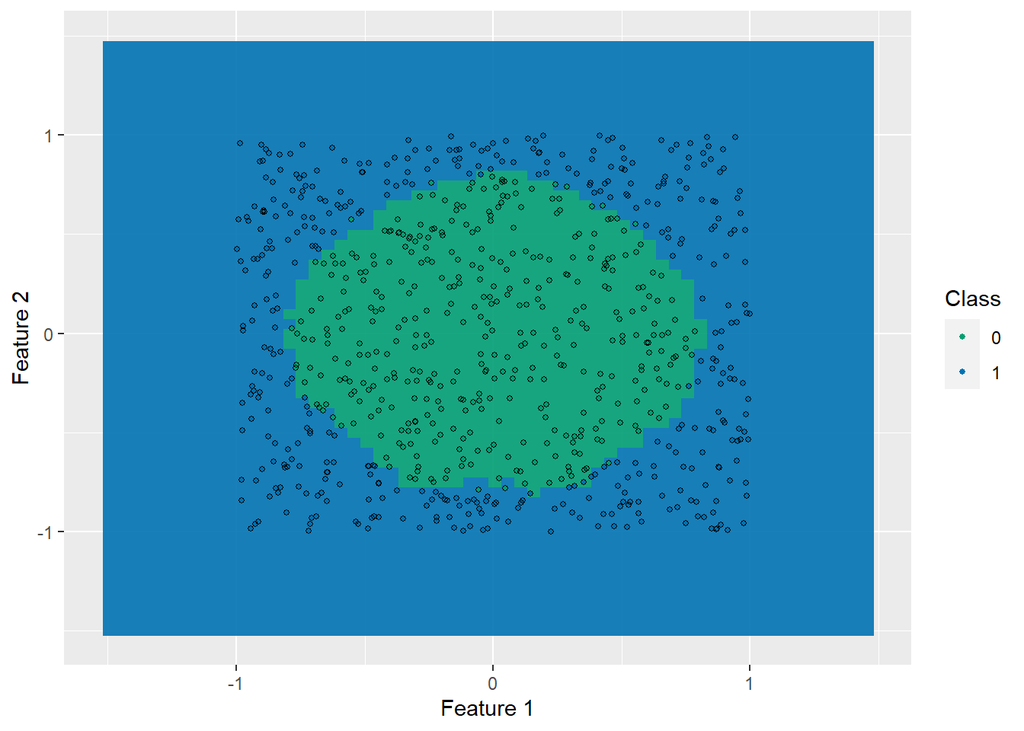

```r
library(ggplot2)
plot_decision_boundary <- function(tr.x, tr.y, pred_grid, grid)
{
cl <- ifelse(tr.Y == 1, "1", "0")
dataf <- data.frame(grid, prob = as.numeric(pred_grid), class = ifelse(pred_grid==2, "1", "0"))
col <- c("#009E73", "#0072B2")
plot <- ggplot(dataf) + geom_raster(aes(x=X.1, y=X.2, fill=prob), alpha=.9, data=dataf) +
geom_point(aes(x=X.1, y=X.2, color=class), size=1,
data=data.frame(X.1=tr.X[,1], X.2=tr.X[,2], class=cl)) +
geom_point(aes(x=X.1, y=X.2), size=1, shape=1,
data=data.frame(X.1=tr.X[,1], X.2=tr.X[,2], class=cl)) +
scale_colour_manual(values=col, name="Class") +
scale_fill_gradientn(colors=col[c(1,2)], limits=c(0,1), guide = FALSE) + xlab("Feature 1") + ylab("Feature 2")
return(plot)
}

tr.X <- train[,1:2]
tr.Y <- train[,3]
te.X <- test[,1:2]
te.Y <- test[,3]
grid <- expand.grid(X.1=seq(min(tr.X[,1]-0.5), max(tr.X[,1]+0.5), by=0.05), X.2=seq(min(tr.X[,2]-0.5), max(tr.X[,2]+0.5), by=0.05))
y_pred15 <- knn(tr.X, te.X, tr.Y, k =15, prob = TRUE)
pred_grid <- as.numeric(knn(tr.X, grid, tr.Y, k=15, prob=TRUE)) - 1
plot_decision_boundary(tr.X, tr.Y, pred_grid, grid)
```

### 3. Performance measures for classification

**Recall the `Caravan` data from the week 2 lab (part of the `ISLR` package). Train a KNN model with k=2 using all the predictors in the dataset and the outcome `Purchase`. Create a confusion matrix with the test set predictions and the actual values of `Purchase`. Using the values of the confusion matrix, calculate precision, recall, and F1. (Note that `Yes` is the positive class and the confusion matrix may be differently oriented than the one presented in class.)**

```r
library(ISLR)
names(Caravan)
```

```
##  [1] "MOSTYPE"  "MAANTHUI" "MGEMOMV"  "MGEMLEEF" "MOSHOOFD" "MGODRK"
##  [7] "MGODPR"   "MGODOV"   "MGODGE"   "MRELGE"   "MRELSA"   "MRELOV"
## [13] "MFALLEEN" "MFGEKIND" "MFWEKIND" "MOPLHOOG" "MOPLMIDD" "MOPLLAAG"
## [19] "MBERHOOG" "MBERZELF" "MBERBOER" "MBERMIDD" "MBERARBG" "MBERARBO"
## [25] "MSKA"     "MSKB1"    "MSKB2"    "MSKC"     "MSKD"     "MHHUUR"
## [31] "MHKOOP"   "MAUT1"    "MAUT2"    "MAUT0"    "MZFONDS"  "MZPART"
## [37] "MINKM30"  "MINK3045" "MINK4575" "MINK7512" "MINK123M" "MINKGEM"
## [43] "MKOOPKLA" "PWAPART"  "PWABEDR"  "PWALAND"  "PPERSAUT" "PBESAUT"
## [49] "PMOTSCO"  "PVRAAUT"  "PAANHANG" "PTRACTOR" "PWERKT"   "PBROM"
## [55] "PLEVEN"   "PPERSONG" "PGEZONG"  "PWAOREG"  "PBRAND"   "PZEILPL"
## [61] "PPLEZIER" "PFIETS"   "PINBOED"  "PBYSTAND" "AWAPART"  "AWABEDR"
## [67] "AWALAND"  "APERSAUT" "ABESAUT"  "AMOTSCO"  "AVRAAUT"  "AAANHANG"
## [73] "ATRACTOR" "AWERKT"   "ABROM"    "ALEVEN"   "APERSONG" "AGEZONG"
## [79] "AWAOREG"  "ABRAND"   "AZEILPL"  "APLEZIER" "AFIETS"   "AINBOED"
## [85] "ABYSTAND" "Purchase"
```

```r
X <- Caravan[,1:85]
Y <- Caravan[,86]
X <- scale(X)
n_test <- floor(nrow(Caravan) * 0.2)
idx <- sample(1:nrow(Caravan), n_test)
tr.X <- X[-idx,]
te.X <- X[idx,]
tr.Y <- Y[-idx]
te.Y <- Y[idx]
set.seed(1)
pred.Y <- knn(tr.X, te.X, tr.Y, k = 2)
matrix <- table(te.Y, pred.Y)
matrix
```

```
##      pred.Y
## te.Y    No  Yes
##   No  1027   70
##   Yes   59    8
```

```r
TP <- matrix['Yes', 'Yes']
FP <- matrix['No', 'Yes']
TN <- matrix['No', 'No']
FN <- matrix['Yes', 'No']
Precision = TP/ (TP + FP)
Precision
```

```
## [1] 0.1025641
```

```r
Recall = TP/ (TP + FN)
Recall
```

```
## [1] 0.119403
```

```r
F1 = 2*((Precision*Recall)/(Precision+Recall))
F1
```

```
## [1] 0.1103448
```